# Exercício Análise de Crédito - FIA

Marcio Cruz

31/05/2021

### a) Qual a idade média dos clientes presentes no banco de dados?

Resp: A idade média dos clientes é de 80.73 anos.

### b) Qual o valor do mínimo, máximo, mediana, Q1 e Q3 da variável idade? Interprete os valores

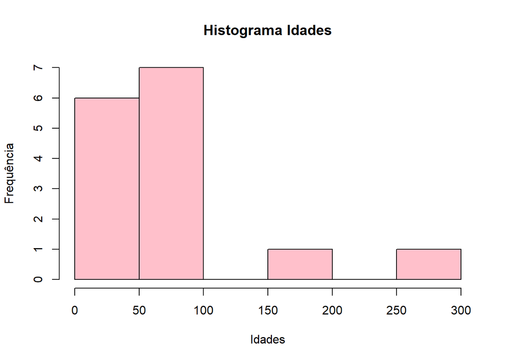

**Valores:**

- Min: 32
- Max: 300
- Mediana: 56
- Q1: 44.5
- Q3: 72

**Interpretação:**

### c) Existem clientes com idades discrepantes? Analise o boxplot.

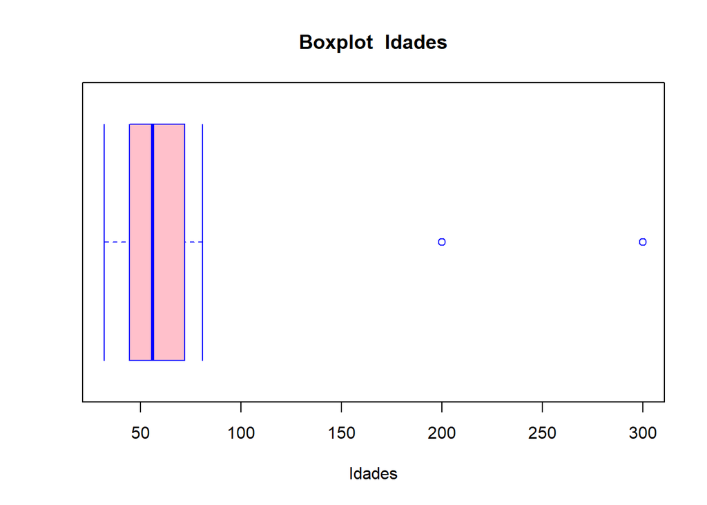

### d) Existem clientes que possuem rendimento total discrepante em relação aos demais clientes? Analise o boxplot.

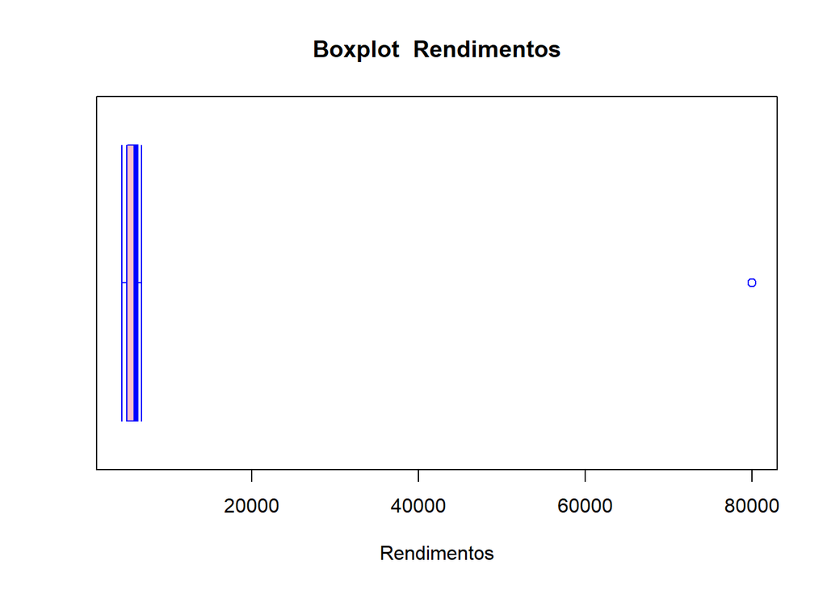

**Interpretação:**

- Existem 1 clientes que possuem rendimentos discrepantes na base analisada.

### e) A partir de qual valor o rendimento é considerado discrepante?

- Rendimentos com valor acima de R$ 8400.00 são considerados discrepantes.

### f) A variável rendimento total pode ser considerada simétrica?

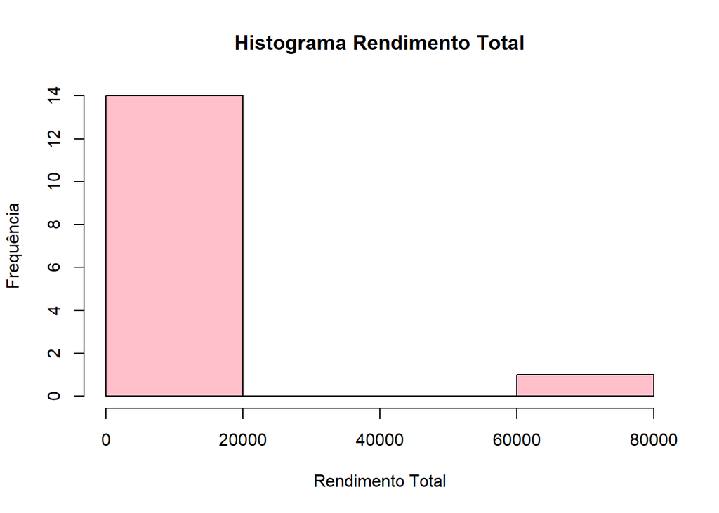

**Interpretação:**

- Média: 10601.33
- Mediana: 6000.00
- A variável Rendimento Total possui coeficiente de assimétria igual a 3.4658, portanto, assimétrica a direita.

### g) Existem clientes que possuem salário discrepante em relação aos demais clientes? Analise o boxplot.

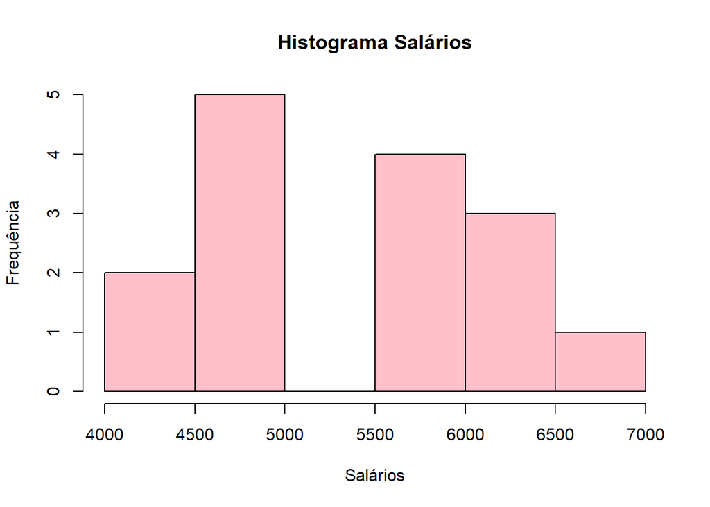

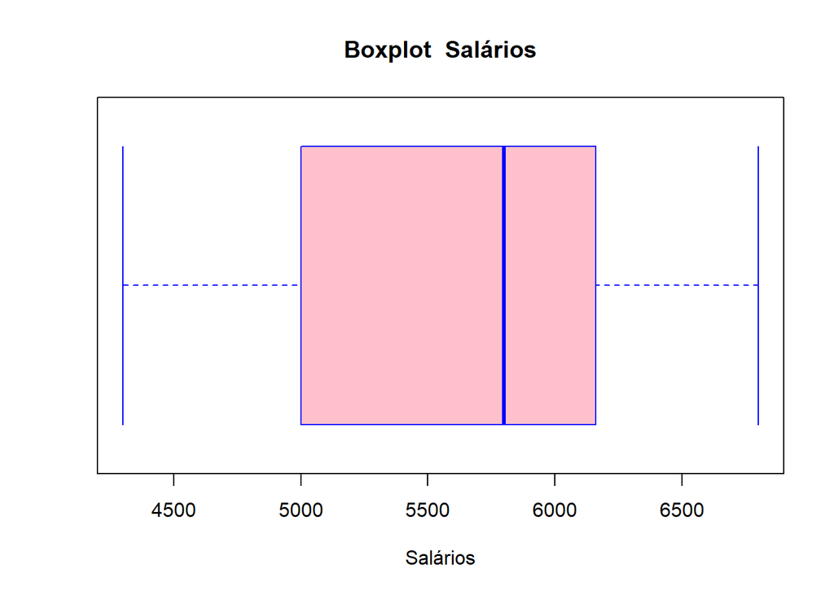

**Interpretação:**

- De acordo com o boxplot e analisando os valores há 0 clientes com salário discrepante.

### i) A variável salário pode ser considerada simétrica?

**Valores:**

- Média: 5554.67
- Mediana: 5800.00

### j) Existem clientes que possuem limite de cheque especial discrepante em relação aos demais clientes? Analise o boxplot.

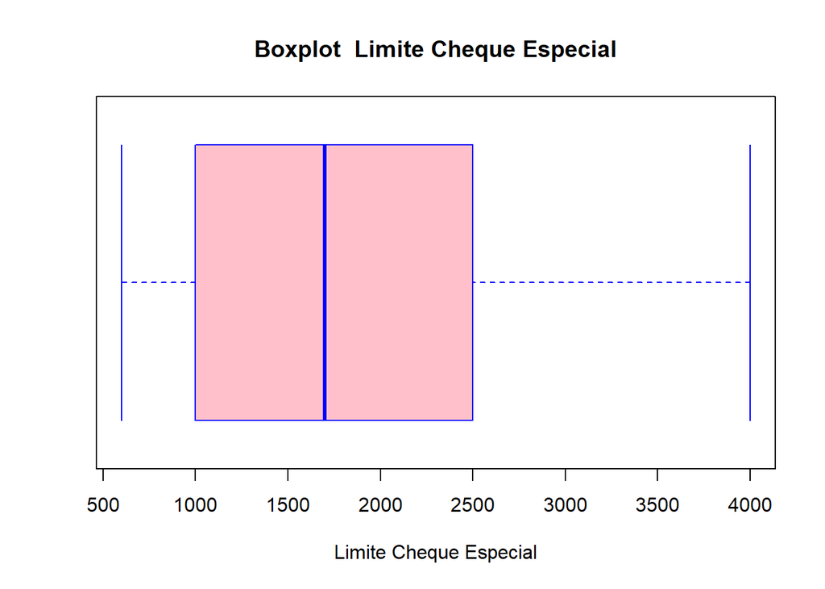

**Interpretação:**

- De acordo com o boxplot e analisando os valores há 0 clientes com cheque especial discrepante.

### k) A partir de qual valor o limite de cheque especial é considerado discrepante?

Limites a partir de R$4750.00 são considerados discrepantes.

### l) A variável limite de cheque especial pode ser considerada simétrica?

**Valores:**

- Média: 1956.00
- Mediana: 1700.00

**Interpretação:**

- A variável possui coeficiente de assimetria de 0.5124, o que confirma que é assimétrica a direita.